## Complete spatial randomness (CSR)

# Complete spatial randomness (CSR)

La CSR è un’ipotesi da verificare prima di procedere a ulteriori Analysis su un point pattern (PP), descrive un processo punto in cui gli eventi punto si verificano all’interno di una determinata area di studio in modo completamente casuale. È sinonimo di un processo spaziale omogeneo di Poisson.

La CSR è vista come la situazione “intermedia” tra strutture spaziali regolari e strutture spaziali clusterizzate. Occorre quindi:

- quantificare la situazione di CSR
- valutare gli “scostamenti” da questa situazione in una direzione o nell’altra
- se lo “scostamento” è elevato si respinge l’ipotesi

## Tipi di test:

1. Test basati sui quadrat counts
2. Test basati sulla distanza
- test grafici
- test Monte Carlo

### Test basato sui quadrat counts

Si individuano $A_1, ..., A_m$ operando una tassellatura di $W$ tramite una collezione di celle quadrate di area a

$N(A_i)$: numero aleatorio di eventi in $A_i$ La CSR implica che $N(A_i) \sim Pois(\lambda a)$.

Il test confronta il numero osservato $n_i$ di eventi in $A_i$ con il numero atteso (costante) sotto $H_0$

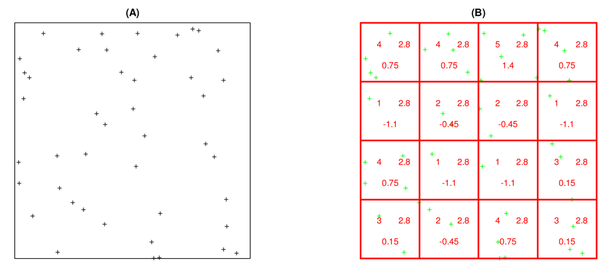

La statistica test racchiude al suo interno l’*indice di dispersione* ossia il rapporto tra la varianza e la media:

$$X^2 = \sum_{i=1}^m \frac{(n_i- \overline n)^2}{\overline n} = (m-1) \space \space I$$
Asintoticamente se $\overline n$ non è troppo piccolo può essere approssimato:

$$X^2|H_0 \sim \chi^2_{m-1}$$

Dove $n_i$ sono il numero degli eventi nelle i-esime celle, $\overline n = \frac{\sum n_i}{m}$ $I$ = indice di dispersione, ossia:

$$I= \frac{S^2}{\overline n}$$

### Test basati sulle distanze

Confronto tra la funzione di ripartizione campionaria (empirica) di una qualche distanza relativa ai punti del PP e quella attesa sotto CSR (quindi sotto $H_0$).

*Tipi di distanza tra punti del point pattern*

- Inter event distances
- Nearest neighbour distance
- Point to Nearest Event distance

*Nearest neighbour distance*

Funzione di ripartizione di R sotto $H_0$ (ipotesi di CSR):

$$G(r)= 1-\exp(- \lambda \pi r^2)$$

Funzione di ripartizioe empirica di R valutata in r:

$$\hat G_0(r) = \sum_{i=1}^n I(r_i \le r)/n$$

dove $r_i$: distanza fra l’evento $s_i$ e l’evento ad esso più vicino in $W$

### Test grafico

Nel test grafico si esegue un confronto tra $G(t)$ e $\hat G_0(r)$

### Test grafico con sviluppi di Monte Carlo

Si fanno $B\gg0$ replicazione di $\hat G_0(r)$ e si verifica se (e per quali i) la curva empirica esce dall’inviluppo.

La procedura non è un test di significatività in senso usuale ma risulta molto utile nel caso di processi complessi per cui la funzione di ripartizione può non essere nota analiticamente ma si è in grado di simularne traiettorie.

Una curva empirica che fuoriesca per larghi tratti dall’inviluppo sotto $H_0$ indica che il PP osservato supporta poco l’ipotesi CSR.

*Vantaggi*

- flessibilità sulla scelta della statistica test
- test valido per campioni di ampiezza qualsiasi (approssimazione numerica legata al numero K di iterate effettuate)

*Svantaggi*

- bassa potenza: il test ha un’ipotesi alternativa generica (per esempio alternative possibili per CSR sono sia PP non omogenei che regolari o clusterizzati)
- arbitrarietà nella scelta di K